# The Invisible Ocean | D. Flag distribution

T10-T12: which vessel flags carry the fishing hours, and where they fish

## T10 - Which vessel flags dominate?

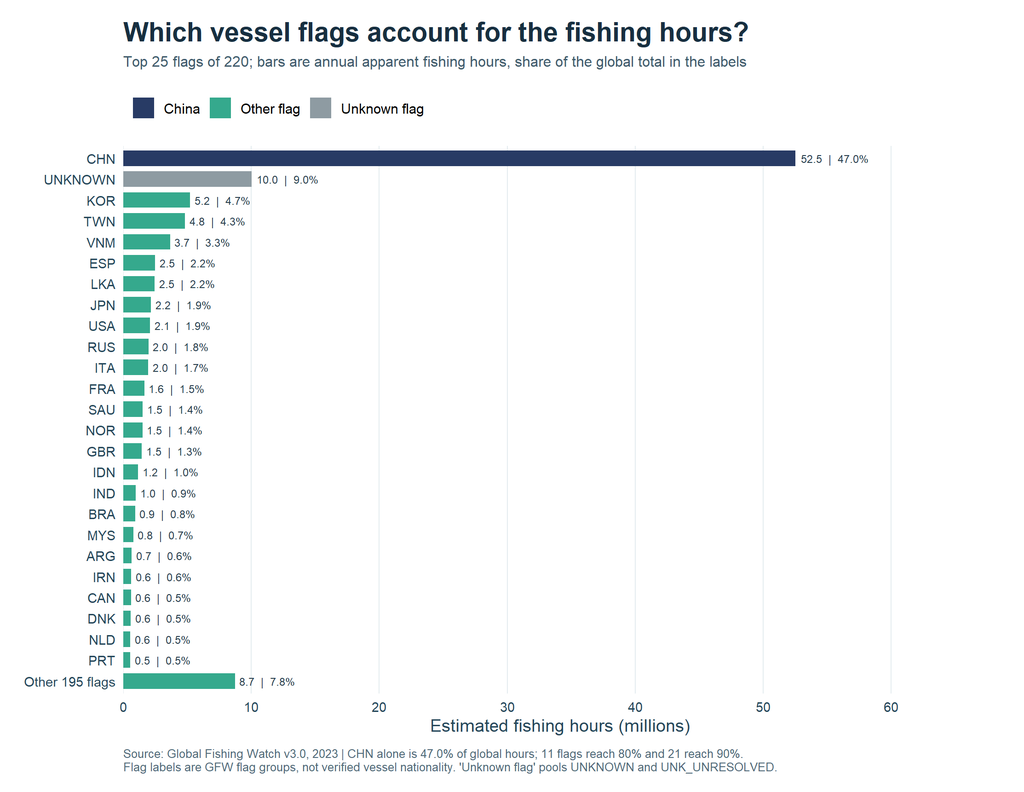

Top ten flag groups by annual apparent fishing hours, 2023.

| Rank | Flag group | Fishing hours | Share of global | Cumulative share |
| --- | --- | --- | --- | --- |
| 1 | CHN | 52,509,582 | 47.0% | 47.0% |
| 2 | UNKNOWN | 10,030,473 | 9.0% | 56.0% |
| 3 | KOR | 5,233,109 | 4.7% | 60.7% |
| 4 | TWN | 4,826,242 | 4.3% | 65.0% |
| 5 | VNM | 3,656,770 | 3.3% | 68.3% |
| 6 | ESP | 2,497,668 | 2.2% | 70.5% |
| 7 | LKA | 2,459,867 | 2.2% | 72.7% |
| 8 | JPN | 2,171,133 | 1.9% | 74.6% |
| 9 | USA | 2,099,963 | 1.9% | 76.5% |
| 10 | RUS | 1,975,143 | 1.8% | 78.3% |

CHN accounts for 47.0% of all 111.71 million estimated fishing hours, and the share is heavily top-heavy: 11 of 220 flag groups reach 80% and 21 reach 90%. The unlabeled `UNKNOWN` group is the second largest entry at 9.0%, larger than every named flag except China. Shares are computed over all recorded hours, so the unknown group is never hidden inside a named flag.

## T11 - How is flag activity distributed by area?

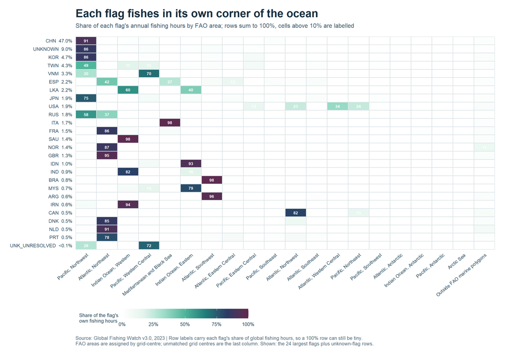

Each cell divides a flag’s hours in one FAO area by **that flag’s own annual total**, so every row sums to 100% and the chart answers “where does this flag fish”. Reading it column-wise would instead answer “who fishes in this area”, which is T12. The rows are the 24 largest flags plus the two unknown groups; the full 1014-row flag-by-area table with every one of the 220 flags is in `results/tables/T11_flag_area.csv`.

The pattern is regional: most flags put nearly all their hours into one or two areas. China concentrates 91.4% in the Northwest Pacific, the United Kingdom 94.9% in the Northeast Atlantic and Indonesia 92.7% in the Eastern Indian Ocean. Only a few distant-water flags, such as Spain, the United States and Taiwan, spread across four or more areas. The last column holds grid centres that fall outside every FAO polygon: it takes 2.1% of all fishing hours, which is small overall but concentrated in flags that work coasts and enclosed seas.

## T12 - What share do the top three known flags contribute per area?

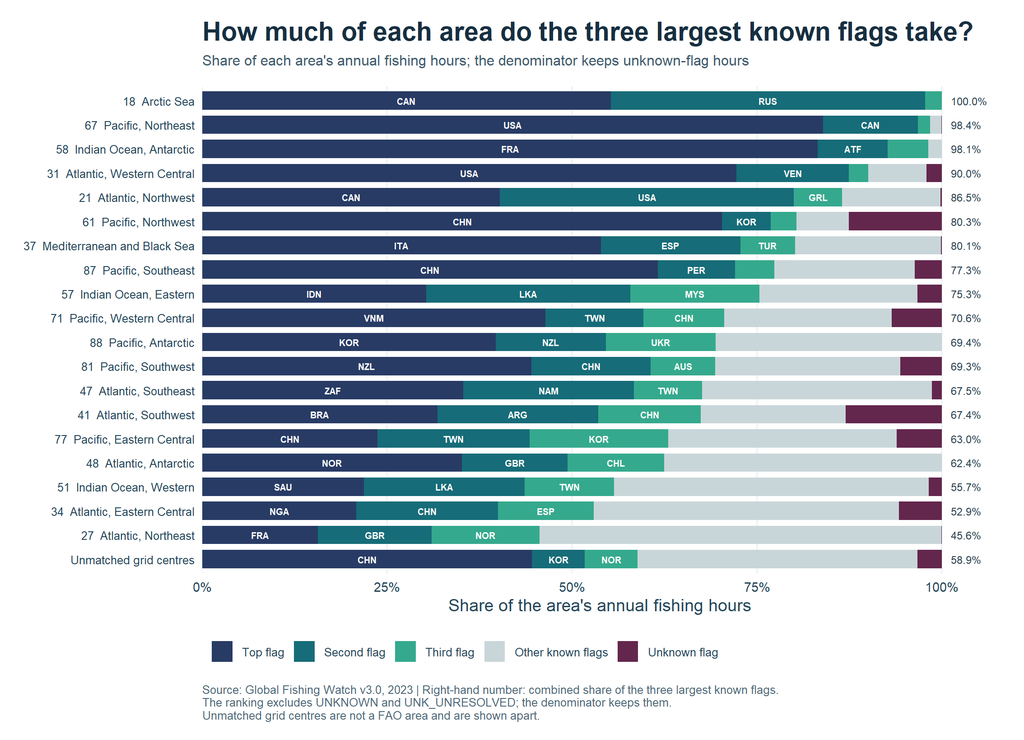

For each area the three largest **known** flags are ranked, and their combined hours are divided by **all hours recorded in that area, including `UNKNOWN` and `UNK_UNRESOLVED`**. That denominator matters: if unknown hours were dropped, a thinly labeled area could report a top-three share near 100% without any flag actually dominating it.

Across the 19 FAO areas the median top-three share is 70.6%. The lowest is Atlantic, Northeast (45.6%), where no flag reaches even a fifth of the area, and the highest are the polar and semi-enclosed areas where a handful of national fleets operate: Arctic Sea reaches 100.0%. That value is 100% only because 3 known flags are recorded there at all, so “top three” means “all three”. The smallest number of known flags in any area is 3, so no area has fewer than three to rank.

Unknown flag hours are uneven. They are 13.0% of Atlantic, Southwest but close to zero in the Northeast Atlantic and the Mediterranean, where fleets are well covered by AIS and well identified. Unmatched grid centres are shown as a separate bar because they are not a FAO area.

## Method and sources

All three tasks read only the annual summary tables of `DS4073_GFW_2023_Shared` (`annual_flag.csv`, `annual_flag_area.csv`, `area_names.csv`); no detail grid file is needed, so the page reruns in seconds. Apparent fishing activity is estimated from AIS (Global Fishing Watch v3.0, 2023) and measured in hours; it is neither landed catch nor a vessel count. `flag` is the raw GFW field and `flag_group` is the analysis label that pools `UNKNOWN-*` codes, so the bars describe **recorded flag classification, not verified vessel nationality**: flags of convenience, re-flagging and AIS gaps all move hours between labels. Every table sums back to 111.71 million hours (tolerance 0.001), and the checks are in `analysis_D.R`; see `results/tables/D_reconciliation.csv`.